# Learning Lab 3 Case Study

Meina Zhu

July 15, 2022

Even after feature engineering, machine learning approaches can often (but not always) be improved by choosing a more sophisticated model type. Note how we used a regression model in the first two case studies; here, we explore a considerably more sophisticated model, a random forest.

Choosing a more sophisticated model adds some complexity to the modeling. Notably, more complex models have *tuning parameters* - parts of the model that are not estimated from the data. In addition to using feature engineering in a way akin to how we did in the last case study, Bertolini et al. (2021) use tuning parameters to improve the performance of their predictive model.

> Bertolini, R., Finch, S. J., & Nehm, R. H. (2021). Enhancing data pipelines for forecasting student performance: integrating feature selection with cross-validation. *International Journal of Educational Technology in Higher Education, 18*(1), 1-23. https://github.com/laser-institute/essential-readings/blob/main/machine-learning/ml-lab-3/bertolini-et-al-2021-ijethe.pdf

Our driving question is: **How much of a difference does a more complex model make?** Looking back to our predictive model from LL1, we can see that our accuracy was around 87%: 0.872, more specifically. Can we improve on that?

While answering this question, we focus not only on estimating, but also on tuning a complex model. The data we use is, again, from the #NGSSchat community on Twitter, as in doing so we can compare the performance of this tuned, complex model to the initial model we used in the first case study.

## Step 0: Loading and setting up

First, let’s load the packages we’ll use—the familiar {tidyverse} and several others focused on modeling. Like in earlier learning labs, click the green arrow to run the code chunk.

#### Your Turn ⤵

Please add to the chunk below code to load three packages we’ve used in both LL1 and LL2 - tidyverse, tidymodels, and here.

```r
library(tidyverse)
library(tidymodels)
library(vip) # a new package we're adding for variable importance measures
library(ranger) # this is needed for the random forest algorithm
library(here)
```

Next, we’ll load the processed data.

*Note*: We created a means of visualizing the threads to make coding them easier; that’s here and it provides a means of seeing what the raw data is like: https://jmichaelrosenberg.shinyapps.io/ngsschat-shiny/.

We’ve added three additional variables for this analysis; thus, the variables we have to consider to use as features are:

1. `n`: The number of tweets in the *thread* (independent variable)
2. `mean_favorite_count`: The mean number of favorites for the tweets in the thread (*independent* variable)
3. `sum_favorite_count`: The sum of the number of favorites for the tweets in the thread (*independent* variable)
4. `mean_retweet_count`: The mean number of retweets for the tweets in the thread (*independent* variable)
5. `sum_retweet_count`: The sum of the number of retweets for the tweets in the thread (*independent* variable)
6. `sum_display_text_width`: The sum of the number of characters for the tweets in the thread (*independent* variable)
7. `mean_display_text_width`: The mean of the number of characters for the tweets in the thread (*independent* variable)
8. `code`: The qualitative code (TS = transactional; TF = transformational) (*dependent* variable)

One *big* type of feature not included in this analysis - more information on the text in the tweets. This is likely to be quite predictive: the words that users included in their tweets are probably associated with (and predictive of) substantive or transactional conversations. Given our focus on ML in this topic area, we do *not include features relating to the text data*, but think this could be a great direction for future work (and research) in this area.

```r
d <- read_csv("data/ngsschat-processed-data.csv")
d <- d %>%
    mutate(code = as.factor(code)) # this is needed for the classification mode
```

## Step 1. Split data

We treat this step relatively minimally as we have now carried out a step very similar to this in LL1 and LL2; return to the case study for those (especially LL1) for more on data splitting. Note that we carry out the *k*-folds cross-validation process introduced in LL2. Consider - like there - setting a different value for *v* (*k*) as you think is appropriate.

#### Your Turn ⤵

You do have one step that is your turn! Please add the code for setting up the k-folds cross-validation (exactly as you did this in LL2.

```r
set.seed(20220712)
train_test_split <- initial_split(d, prop = .80)
data_train <- training(train_test_split)

#<replace this line with your kfcv code!>
kfcv <- vfold_cv(data_train, v = 8)
```

## Step 2: Engineer features

#### Your Turn ⤵

Add a feature engineering step below. Consider those described [here](https://recipes.tidymodels.org/reference/index.html).

```r
my_rec <- recipe(code ~ ., data = data_train) %>%
    step_normalize(all_numeric_predictors()) %>%
    step_nzv(all_predictors()) %>%
    step_dummy(all_nominal_predictors()) %>%  # dummy code all factor variables
    step_impute_knn(all_predictors()) # impute missing data for all predictor variables
```

## Step 3: Specify recipe, model, and workflow

There are several steps that are different from the past learning labs here.

```r
# specify model
my_mod <-
    rand_forest(mtry = tune(),
                min_n = tune(),
                trees = tune ()) %>%
    set_engine("ranger", importance = "impurity") %>%
    set_mode("classification")

# specify workflow
my_wf <-
    workflow() %>%
    add_model(my_mod) %>%
    add_recipe(my_rec)
```

## Step 4: Fit model

These next two functions are used to get a sense of what the values for `mtry` and `min_n` should be based on the dimensions or range of the values of the variables in the data.

```r
finalize(mtry(), data_train)
```

```
## # Randomly Selected Predictors (quantitative)
## Range: [1, 5]
```

```r
finalize(min_n(), data_train)
```

```
## Minimal Node Size (quantitative)
## Range: [2, 40]
```

```r
finalize(trees(), data_train)
```

```
## # Trees (quantitative)
## Range: [1, 2000]
```

#### Your Turn ⤵

We then use these values in the `grid_max_entropy()` function below; replace the `xx` values below with the *maximum* value provided by the `mtry` and `min_n` variables, above. You can see that `tree_grid` is simply a combination of values of the hyperparameters.

```r
tree_grid <- grid_max_entropy(mtry(range(1, 5)),
                              min_n(range(2, 40)),
                              trees(range(1,600)),
                              size = 10)

tree_grid
```

```
## # A tibble: 10 × 3
##     mtry min_n trees
##    <int> <int> <int>
##  1     3    30   358
##  2     4    32   545
##  3     1     2   567
##  4     5     3   141
##  5     1    34   586
##  6     1    24    86
##  7     5     6   486
##  8     2     7   193
##  9     5    34   239
## 10     4    26    59
```

```r
# fit model with tune_grid()
fitted_model <- my_wf %>%
    tune_grid(
        resamples = kfcv,
        grid = tree_grid,
        metrics = metric_set(roc_auc, accuracy, kap, sensitivity, specificity, precision)
    )
```

[output not shown]

[output not shown]

[output not shown]

[output not shown]

[output not shown]

[output not shown]

[output not shown]

[output not shown]

[output not shown]

[output not shown]

[output not shown]

[output not shown]

[output not shown]

[output not shown]

[output not shown]

[output not shown]

[output not shown]

[output not shown]

[output not shown]

[output not shown]

[output not shown]

[output not shown]

[output not shown]

[output not shown]

Here comes some further additional steps. This next step is key technically and conceptually - we’re examining the best tuning parameters *ranked by their predictive accuracy*.

```r
# examine best set of tuning parameters; repeat?
show_best(fitted_model, n = 10, metric = "accuracy")
```

```
## # A tibble: 10 × 9
##     mtry trees min_n .metric  .estimator  mean     n std_err .config
##    <int> <int> <int> <chr>    <chr>      <dbl> <int>   <dbl> <chr>
##  1     4    59    26 accuracy binary     0.884     8 0.00402 Preprocessor1_Mode…
##  2     3   358    30 accuracy binary     0.881     8 0.00396 Preprocessor1_Mode…
##  3     2   193     7 accuracy binary     0.881     8 0.00565 Preprocessor1_Mode…
##  4     4   545    32 accuracy binary     0.881     8 0.00344 Preprocessor1_Mode…
##  5     1   567     2 accuracy binary     0.880     8 0.00563 Preprocessor1_Mode…
##  6     5   239    34 accuracy binary     0.879     8 0.00346 Preprocessor1_Mode…
##  7     1    86    24 accuracy binary     0.878     8 0.00525 Preprocessor1_Mode…
##  8     1   586    34 accuracy binary     0.876     8 0.00548 Preprocessor1_Mode…
##  9     5   486     6 accuracy binary     0.865     8 0.00537 Preprocessor1_Mode…
## 10     5   141     3 accuracy binary     0.862     8 0.00556 Preprocessor1_Mode…
```

This function simply indicates that you want to use the best of the sets of tuning parameters examined though the code in the above chunk - literally the first row.

```r
# select best set of tuning parameters
best_tree <- fitted_model %>%
    select_best(metric = "accuracy")
```

Next, we’ll finalize workflow with best set of tuning parameters and then fit the model on the training data.

```r
final_wf <- my_wf %>%
    finalize_workflow(best_tree)

final_fit <- final_wf %>%
    last_fit(train_test_split, metrics = metric_set(roc_auc, accuracy, kap, sensitivity, specificity, precision))
```

We can see that `final_fit` is for a single fit: a random forest with the best performing tuning parameters trained with the *entire* training set of data to predict the values in our (otherwise not used/“spent”) testing set of data.

```r
final_fit
```

```
## # Resampling results
## # Manual resampling
## # A tibble: 1 × 6
##   splits             id               .metrics .notes   .predictions .workflow
##   <list>             <chr>            <list>   <list>   <list>       <list>
## 1 <split [3034/759]> train/test split <tibble> <tibble> <tibble>     <workflow>
```

## Step 5: Interpret accuracy

Last, we can interpret the accuracy of our tuned model.

```r
# fit stats
final_fit %>%
    collect_metrics()
```

```
## # A tibble: 6 × 4
##   .metric     .estimator .estimate .config
##   <chr>       <chr>          <dbl> <chr>
## 1 accuracy    binary         0.877 Preprocessor1_Model1
## 2 kap         binary         0.752 Preprocessor1_Model1
## 3 sensitivity binary         0.885 Preprocessor1_Model1
## 4 specificity binary         0.871 Preprocessor1_Model1
## 5 precision   binary         0.842 Preprocessor1_Model1
## 6 roc_auc     binary         0.932 Preprocessor1_Model1
```

- *Accuracy*: For the known codes, what percentage of the predictions are correct
- *Cohen’s K*: Same as accuracy, while account for the base rate of (chance) agreement
- *Sensitivity (AKA recall)*: Among the true “positives”, what percentage are classified as “positive”?
- *Specificity*: Among the true “negatives”, what percentage are classified as “negative”?
- *ROC AUC*: For different levels of the threshold, what is the sensitivity and specificity?

You’ll have the chance to interpret these further in the badge for this learning lab.

One last note - we may be interested to see which variables were most importance. We can do this with the following.

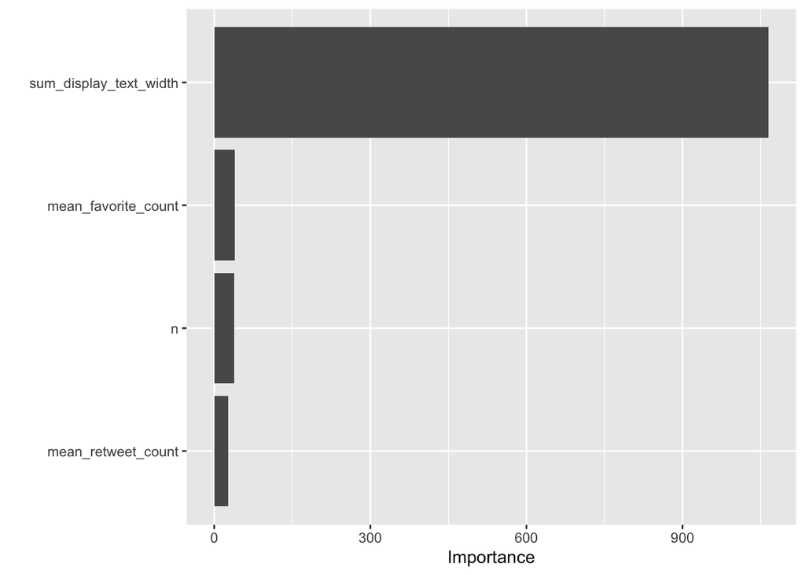

```r
final_fit %>%
    pluck(".workflow", 1) %>%
    extract_fit_parsnip() %>%
    vip(num_features = 10)
```

### 🧶 Knit & Check ✅

Congratulations - you’ve completed this case study! Consider moving on to the badge activity next.